# Bayesian Modeling Problem Set 4 & 5

6. A second random predictor should move the means, but the prediction should still be horrible. Time to run the rest of the models! Create a simple for-loop from `3:30`, where for each `i` you run the model with `i` predictors and store output into the `i`’th element of your list. (Keep the header to suppress model processing in your knit file.)

```r
for (i in 3:30){
  penguin.mods[[i]]=penguin.predict(i,predicts,penguin)
}
```

7. You should now have a full `penguin.mods` list with 30 JAGS objects, each predicting penguin counts with increasing numbers of totally random predictors. Now is the time to see if random variables can perfectly predict data if you use enough! Instead of plotting all 30 PPD plots, just choose 5 more to display. Your code (above) should already have plots for 1 predictor (A.7) and for 2 predictors (B.5). Pick an additional 5 plots with varying numbers of predictors. One *must* be the maximal model with 30 predictors. Make sure each plot is clearly labeled with the number of predictors used.

```r
#5 variables
ppd_mods_5=MCMCchains(penguin.mods[[5]],params="penguin.pred")
sim_mean_mods_5=apply(ppd_mods_5, 1, mean)
obs_mean_mods_5=mean(penguin)

hist(sim_mean_mods_5,breaks=20,main="n.pred=5",xlab="Simulated Means",ylab="Frequency")
abline(v=mean(obs_mean_mods_5),col="red",lwd=2,lty=2)
legend("topright",legend ="Observed mean",col="red",lty=2,lwd=2)
```

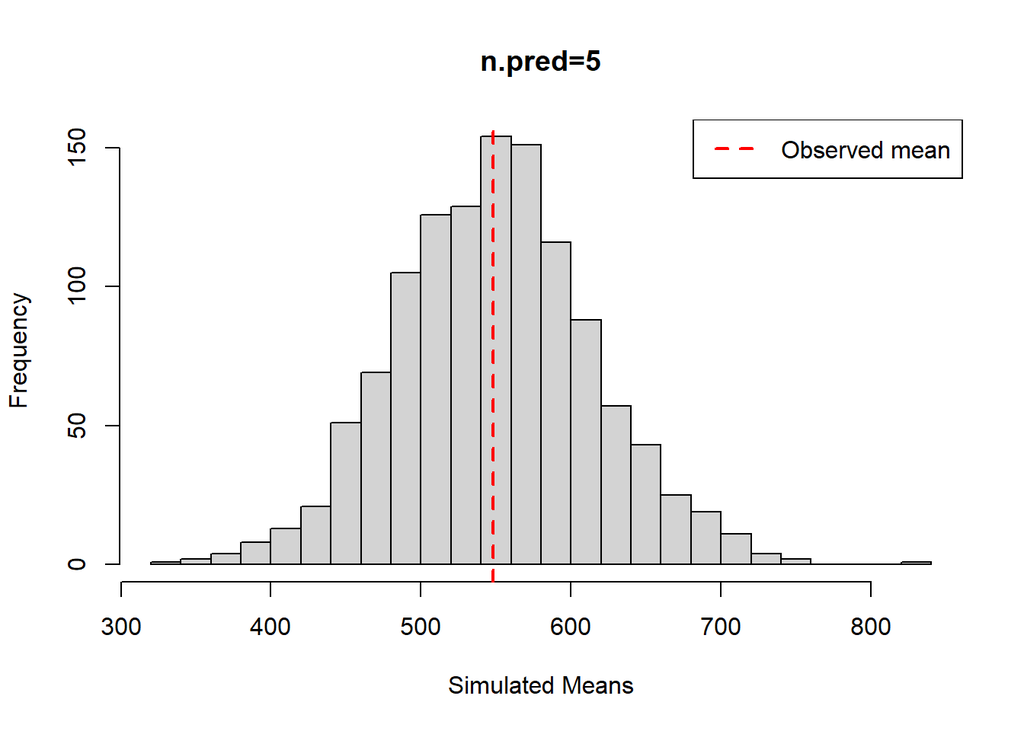

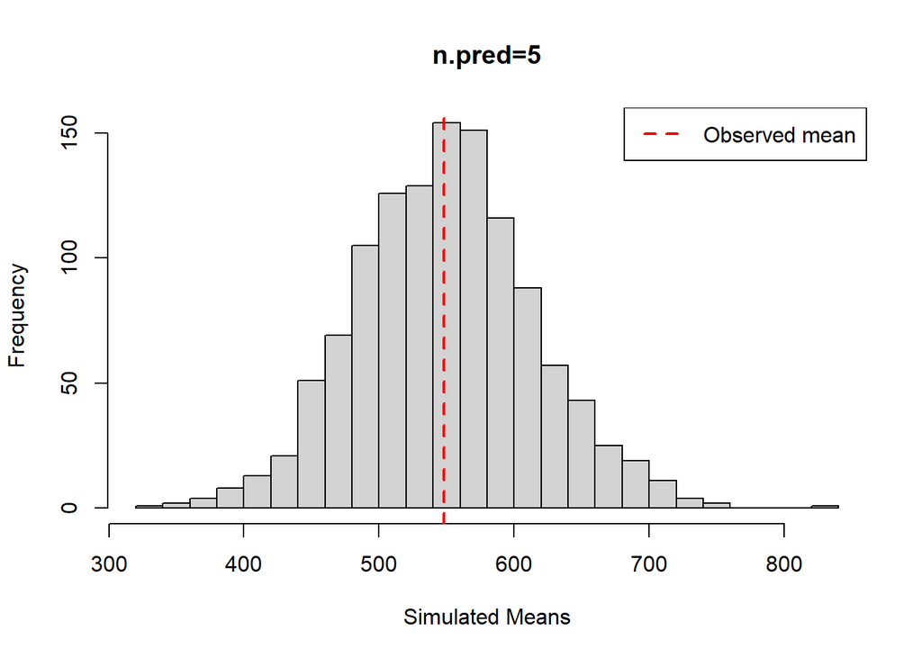

```r
ppd_mean_colony=apply(ppd_mods_5,2,mean)
ppd_mean_colony_lower_95=apply(ppd_mods_5,2,quantile,probs=0.025)
ppd_mean_colony_upper_95=apply(ppd_mods_5,2,quantile,probs=0.975)

df_5=data.frame(obs=penguin,sim_mean=ppd_mean_colony,lower=ppd_mean_colony_lower_95,upper=ppd_mean_colony_upper_95)

ggplot(df_5,aes(x=obs,y=sim_mean))+
  geom_point(col="blue",size=2)+
  geom_errorbar(aes(ymin=lower,ymax=upper), width=0.1, color="black")+
  geom_abline(intercept=0,slope=1,linetype="dashed",color="red")+
  coord_cartesian(xlim=c(0, 1200),ylim=c(0, 1200))+
  labs(x="Observed penguin count",y="Smulated penguin count",title ="n.pred=5")
```

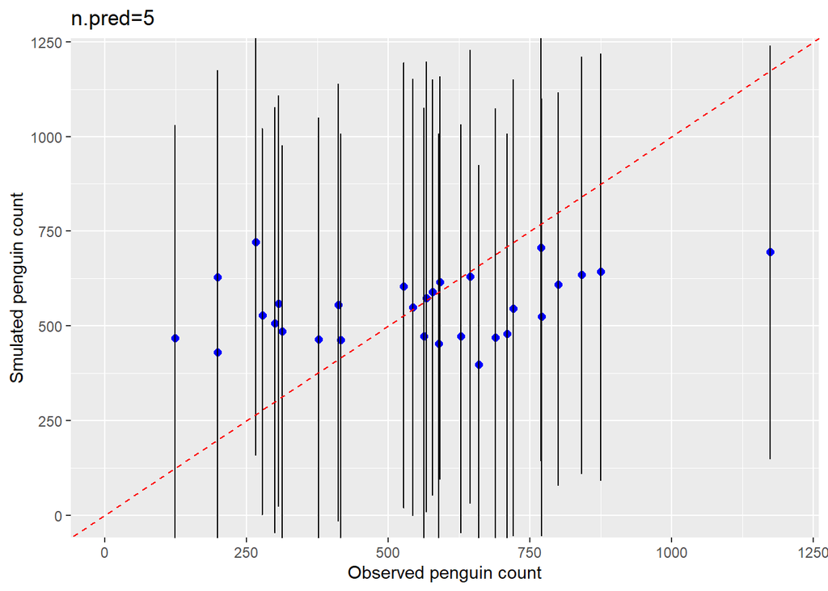

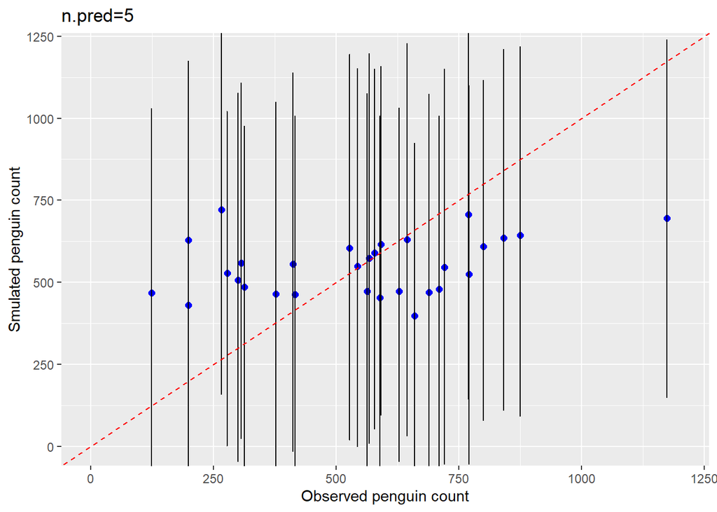

```r
#10 variables
ppd_mods_10=MCMCchains(penguin.mods[[10]],params="penguin.pred")
sim_mean_mods_10=apply(ppd_mods_10, 1, mean)
obs_mean_mods_10=mean(penguin)

hist(sim_mean_mods_10,breaks=20,main="n.pred=10",xlab="Simulated Means",ylab="Frequency")
abline(v=mean(obs_mean_mods_10),col="red",lwd=2,lty=2)
legend("topright",legend ="Observed mean",col ="red",lty=2,lwd=2)
```

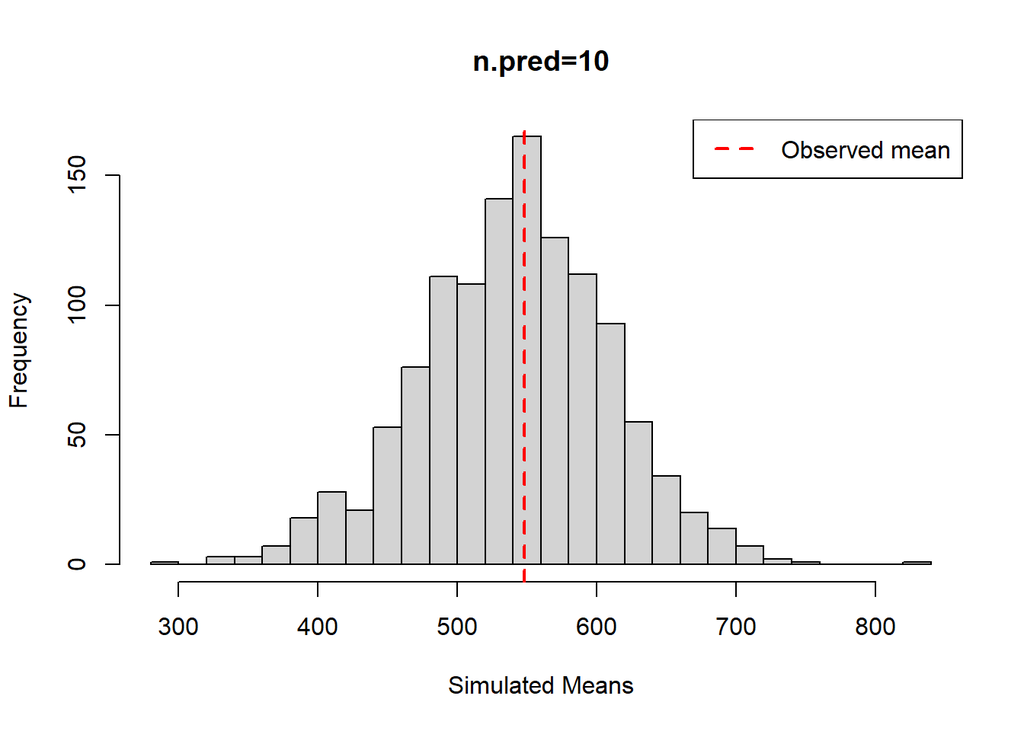

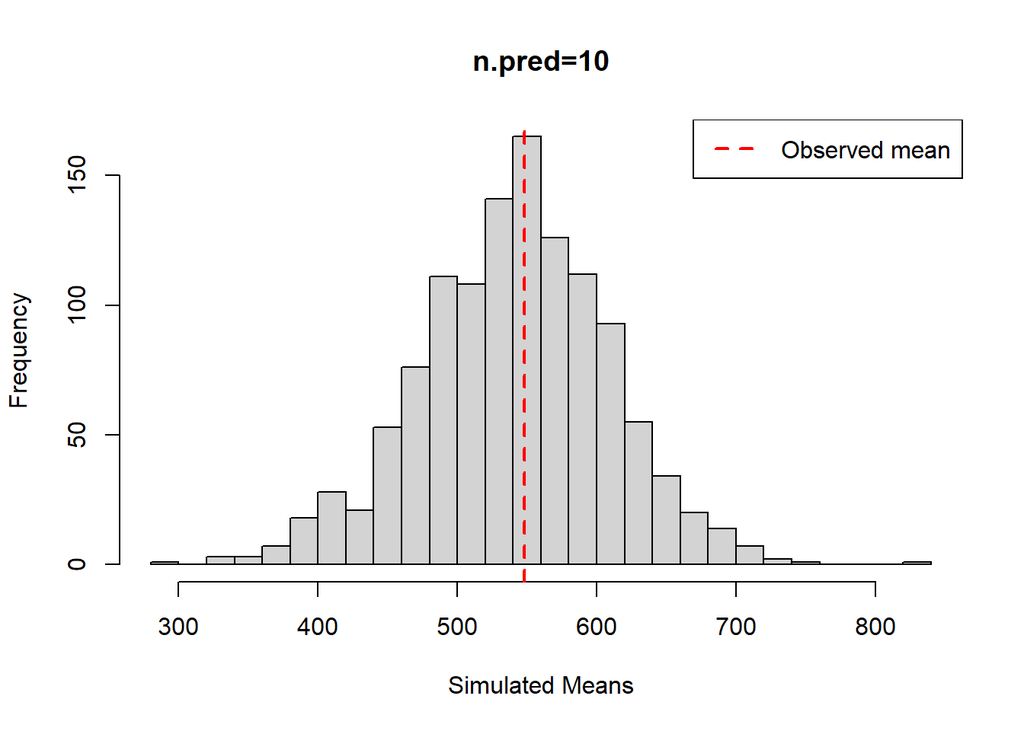

```r
ppd_mean_colony=apply(ppd_mods_10,2,mean)
ppd_mean_colony_lower_95=apply(ppd_mods_10,2,quantile,probs=0.025)
ppd_mean_colony_upper_95=apply(ppd_mods_10,2,quantile,probs=0.975)

df_10=data.frame(obs=penguin,sim_mean=ppd_mean_colony,lower=ppd_mean_colony_lower_95,upper=ppd_mean_colony_upper_95)

ggplot(df_10,aes(x=obs,y=sim_mean))+
  geom_point(col="blue",size=2)+
  geom_errorbar(aes(ymin=lower,ymax=upper),width=0.1,color="black")+
  geom_abline(intercept=0,slope=1,linetype="dashed",color="red")+
  coord_cartesian(xlim=c(0,1200),ylim=c(0,1200))+
  labs(x="Observed penguin count",y="Smulated penguin count",title ="n.pred=10")
```

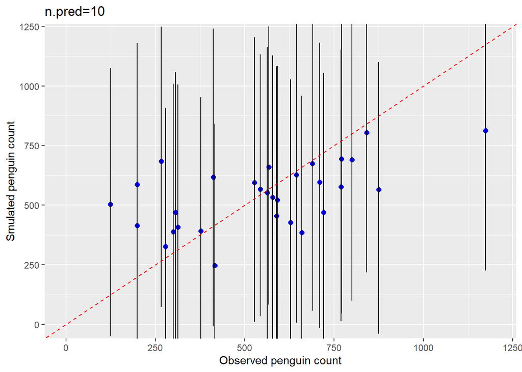

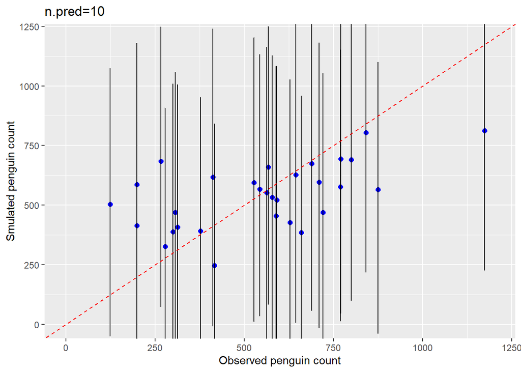

```r
#15 variables
ppd_mods_15=MCMCchains(penguin.mods[[15]],params="penguin.pred")
sim_mean_mods_15=apply(ppd_mods_15, 1, mean)
obs_mean_mods_15=mean(penguin)

hist(sim_mean_mods_15,breaks=20,main="n.pred=15",xlab="Simulated Means",ylab="Frequency")
abline(v=mean(obs_mean_mods_15),col="red",lwd=2,lty=2)
legend("topright",legend ="Observed mean",col ="red",lty=2,lwd=2)
```